# ML-Project-Updated

### Group-1 - Final project submission.

Team members

- Anil Nair
- Maadhu K
- Prasad
- Kedar
- Hiran

Dataset used:- **Bank Marketing Data Set** (https://archive.ics.uci.edu/ml/datasets/bank+marketing)

```python
import pandas as pd
import os
import numpy as np
from sklearn.metrics import confusion_matrix
import matplotlib.pyplot as plt
import seaborn as sns
%matplotlib inline
```

```python
bank_add_full = pd.read_csv('bank-additional-full.csv',sep=';')
```

### bank_add_full data with shape of 41188 x 21 will be used for modelling.

- age
- job
- marital
- education
- default
- housing
- loan
- contact
- month
- day_of_week
- duration
- pdays
- previous
- poutcome
- emp.var.rate
- cons.price.idx
- cons.conf.idx
- euribor3m
- nr.employed
- y

### Performing exploratory data analysis for the category variables in the dataset.

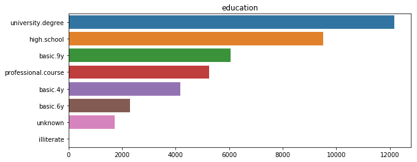

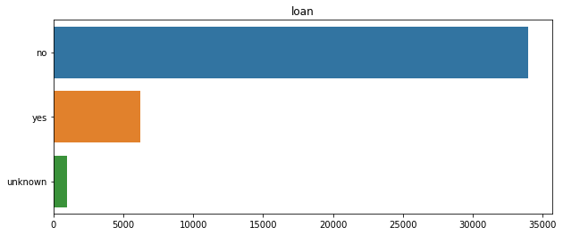

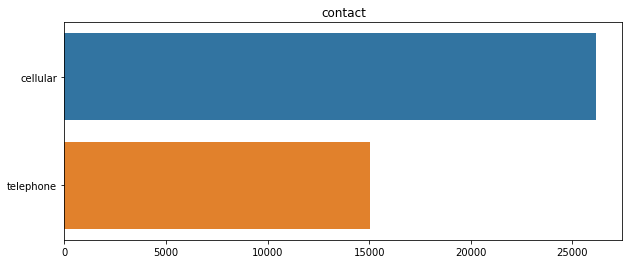

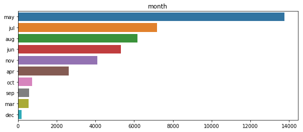

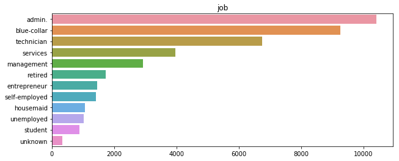

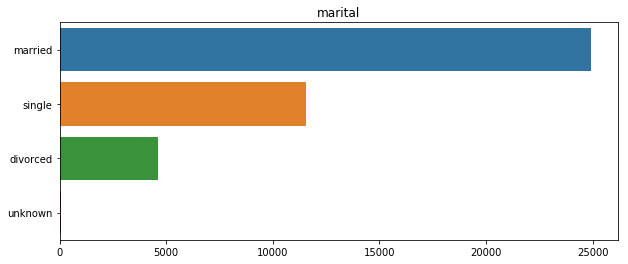

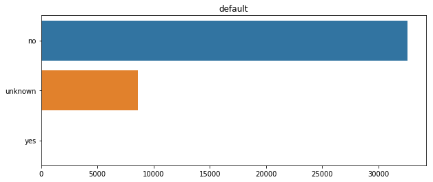

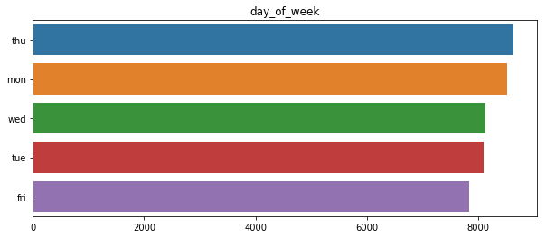

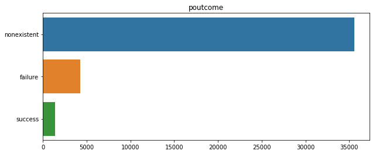

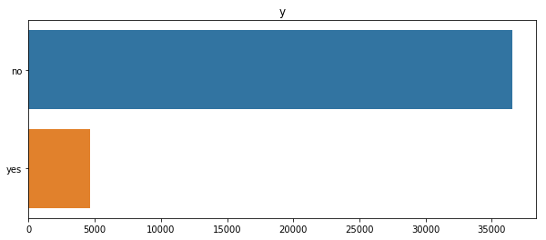

```python
categ_vars = ['education', 'loan', 'contact', 'month', 'job', 'marital',  'default', 'day_of_week', 'poutcome','y']
for col in categ_vars:
    plt.figure(figsize=(10,4))
    sns.barplot(bank_add_full[col].value_counts().values, bank_add_full[col].value_counts().index)
    plt.title(col)
```

#### Since the duration of the call is variable which will be obtained after the completion of the call itself, including this

#### predictor will not be accurate. Hence dropping the variable 'duration' from the dataset.

```python
#Dropping the duration column
bank_add_full.drop('duration',axis=1,inplace=True)
```

#### For all the categorical variables in the data set, we are adding dummy variables to represent the multiple levels.

```python
# Function to create dummy variables for an input categorical column

def encode_categ_vars(var,df):

    #Generating dummies for input variable
    var_dummies=pd.get_dummies(df[var],prefix=var)

    #Dropping one column from the dummy vars to avoid collinearity
    var_dummies=var_dummies.drop(var_dummies.columns[0],axis=1)

    # #Appending the dummy variables to the original dataset.
    df = df.join(var_dummies)

    #Dropping the original variable from dataset
    df.drop(var,axis=1,inplace=True)

    return(df)
```

```python
#Generate dummies for job column
bank_add_full=encode_categ_vars('job',bank_add_full)
```

```python
#Generate dummies for marital column
bank_add_full=encode_categ_vars('marital',bank_add_full)
```

```python
#Generate dummies for education column
bank_add_full=encode_categ_vars('education',bank_add_full)
```

```python
#Generate dummies for default column
bank_add_full=encode_categ_vars('default',bank_add_full)
```

```python
#Generate dummies for housing column
bank_add_full=encode_categ_vars('housing',bank_add_full)
```

```python
#Generate dummies for loan column
bank_add_full=encode_categ_vars('loan',bank_add_full)
```

```python
#Generate dummies for contact column
bank_add_full=encode_categ_vars('contact',bank_add_full)
```

```python
#Generate dummies for month column
bank_add_full=encode_categ_vars('month',bank_add_full)
```

```python
#Generate dummies for day_of_week column
bank_add_full=encode_categ_vars('day_of_week',bank_add_full)
```

```python
#Generate dummies for poutcome column
bank_add_full=encode_categ_vars('poutcome',bank_add_full)
```

| pdays | pdays |
| --- | --- |
| 0 | 15 |
| 1 | 26 |
| 2 | 61 |
| 3 | 439 |
| 4 | 118 |
| 5 | 46 |
| 6 | 412 |
| 7 | 60 |
| 8 | 18 |
| 9 | 64 |
| 10 | 52 |
| 11 | 28 |
| 12 | 58 |
| 13 | 36 |
| 14 | 20 |
| 15 | 24 |
| 16 | 11 |
| 17 | 8 |
| 18 | 7 |
| 19 | 3 |
| 20 | 1 |
| 21 | 2 |
| 22 | 3 |
| 25 | 1 |
| 26 | 1 |
| 27 | 1 |
| 999 | 39673 |

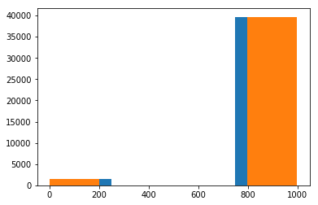

```python
plt.hist(bank_add_full['pdays'], bins=4)
plt.hist(bank_add_full['pdays'], bins=5)
bank_add_full.groupby('pdays')['pdays'].agg({'pdays':'count'})
```

#### As a workaround, the values are converted in to bins. Following dummy columns were added.

- pdays_0_7
- pdays_8-15
- pdays_16_23
- pdays_24_31
- pdays_never_contacted

```python
pdays_0_7 = bank_add_full['pdays'].map(lambda x:1 if x <=7 else 0)
pdays_8_15 = bank_add_full['pdays'].map(lambda x:1 if x <=15 and x >=8 else 0)
pdays_16_23 = bank_add_full['pdays'].map(lambda x:1 if x <=23 and x >=16 else 0)
pdays_24_31 = bank_add_full['pdays'].map(lambda x:1 if x <=31 and x >=24 else 0)
pdays_never_contacted = bank_add_full['pdays'].map(lambda x:1 if x >=32 else 0)
```

```python
pd_df = pd.DataFrame({'pdays_0_7':pdays_0_7,'pdays_8_15':pdays_8_15,'pdays_16_23':pdays_16_23,\
                      'pdays_24_31':pdays_24_31,'pdays_never_contacted':pdays_never_contacted})
bank_add_full = bank_add_full.join(pd_df)
bank_add_full = bank_add_full.drop('pdays',axis=1)

#Dropping one of the dummy columns to avoid collinearity
bank_add_full=bank_add_full.drop('pdays_24_31',axis=1)
```

### As the objective here is to identify if the customer will subscribe to a term deposit, we are using the logistic regression model to predict the binary classification outcome.

```python
from sklearn.model_selection import train_test_split
X_train,X_test,Y_train,Y_test = train_test_split(bank_add_full.drop('y',axis=1),bank_add_full['y'],test_size = 0.3,\
                                                random_state = 123)
```

Using statsmodel package to build a binomial GLM.

```python
import statsmodels.api as sm
X_train = sm.add_constant(X_train)
Y_train = Y_train.map(lambda x: 1 if str(x) == 'yes' else 0)
Y_test = Y_test.map(lambda x: 1 if str(x) == 'yes' else 0)
Y_train.describe()
```

```
count    28831.000000
mean         0.112518
std          0.316008
min          0.000000
25%          0.000000
50%          0.000000
75%          0.000000
max          1.000000
Name: y, dtype: float64
```

**Using backward elimination technique for stepwise regression to remove the statistically insignificant predictors.**

- Assuming confidence level of 95%

Since majority of the predictors in the dataset are categorical values, if one of the levels of the predictor is found insignificant in a step, all the levels of that predictor is removed for the next iteration.

**Iteration - 1**

- All predictors are used

```python
logit = sm.GLM(Y_train, X_train, family=sm.families.Binomial())
result = logit.fit()
print(result.summary2())
```

```
                            Results: Generalized linear model
=========================================================================================
Model:                      GLM                      AIC:                    16038.7789
Link Function:              logit                    BIC:                    -279577.9066
Dependent Variable:         y                        Log-Likelihood:         -7964.4
Date:                       2018-11-23 20:02         LL-Null:                -10141.
No. Observations:           28831                    Deviance:               15929.
Df Model:                   54                       Pearson chi2:           2.93e+04
Df Residuals:               28776                    Scale:                  1.0000
Method:                     IRLS
-----------------------------------------------------------------------------------------
                                Coef.    Std.Err.     z     P>|z|     [0.025     0.975]
-----------------------------------------------------------------------------------------
const                         -217.4782 16754.6668  -0.0130 0.9896 -33056.0216 32621.0652
age                              0.0022     0.0025   0.8453 0.3979     -0.0028     0.0071
campaign                        -0.0399     0.0109  -3.6474 0.0003     -0.0613    -0.0184
previous                        -0.0169     0.0654  -0.2588 0.7958     -0.1451     0.1113
emp.var.rate                    -1.5921     0.1507 -10.5651 0.0000     -1.8875    -1.2968
cons.price.idx                   2.1409     0.2653   8.0703 0.0000      1.6210     2.6609
cons.conf.idx                    0.0240     0.0083   2.8853 0.0039      0.0077     0.0404
euribor3m                        0.2710     0.1365   1.9846 0.0472      0.0034     0.5386
nr.employed                      0.0070     0.0032   2.1581 0.0309      0.0006     0.0134
job_blue-collar                 -0.2211     0.0820  -2.6974 0.0070     -0.3817    -0.0604
job_entrepreneur                -0.0450     0.1267  -0.3549 0.7226     -0.2933     0.2033
job_housemaid                   -0.1633     0.1577  -1.0355 0.3004     -0.4723     0.1458
job_management                  -0.1198     0.0905  -1.3248 0.1852     -0.2971     0.0575
job_retired                      0.1241     0.1138   1.0899 0.2758     -0.0990     0.3472
job_self-employed               -0.0488     0.1224  -0.3989 0.6900     -0.2888     0.1911
job_services                    -0.1578     0.0896  -1.7622 0.0780     -0.3334     0.0177
job_student                      0.2251     0.1177   1.9126 0.0558     -0.0056     0.4557
job_technician                   0.0038     0.0739   0.0509 0.9594     -0.1411     0.1486
job_unemployed                  -0.0755     0.1322  -0.5711 0.5679     -0.3346     0.1836
job_unknown                     -0.2057     0.2574  -0.7991 0.4242     -0.7101     0.2987
marital_married                  0.0955     0.0728   1.3117 0.1896     -0.0472     0.2383
marital_single                   0.1673     0.0827   2.0226 0.0431      0.0052     0.3293
marital_unknown                 -0.2263     0.4888  -0.4630 0.6434     -1.1844     0.7318
education_basic.6y               0.2415     0.1222   1.9761 0.0481      0.0020     0.4810
education_basic.9y               0.0015     0.0994   0.0154 0.9877     -0.1933     0.1963
education_high.school            0.0411     0.0963   0.4273 0.6691     -0.1476     0.2299
education_illiterate             0.9496     0.7934   1.1969 0.2313     -0.6054     2.5047
```

[output cut: 15 more lines]

```
month_may                       -0.3802     0.0864  -4.4017 0.0000     -0.5494    -0.2109
month_nov                       -0.4778     0.1250  -3.8216 0.0001     -0.7228    -0.2327
month_oct                        0.0050     0.1606   0.0314 0.9750     -0.3096     0.3197
month_sep                        0.3176     0.1908   1.6642 0.0961     -0.0564     0.6916
day_of_week_mon                 -0.2270     0.0691  -3.2859 0.0010     -0.3624    -0.0916
day_of_week_thu                  0.0677     0.0664   1.0204 0.3076     -0.0624     0.1978
day_of_week_tue                  0.0511     0.0684   0.7469 0.4551     -0.0830     0.1852
day_of_week_wed                  0.1329     0.0682   1.9499 0.0512     -0.0007     0.2666
poutcome_nonexistent             0.4925     0.1026   4.7989 0.0000      0.2914     0.6937
poutcome_success                 0.5699     0.2564   2.2230 0.0262      0.0674     1.0723
pdays_0_7                      -20.2838 16754.6188  -0.0012 0.9990 -32858.7332 32818.1656
pdays_8_15                     -20.1941 16754.6188  -0.0012 0.9990 -32858.6435 32818.2554
pdays_16_23                    -21.3630 16754.6188  -0.0013 0.9990 -32859.8125 32817.0864
pdays_never_contacted          -21.4949 16754.6188  -0.0013 0.9990 -32859.9444 32816.9545
=========================================================================================
```

**Iteration -2**

```python
#Removing pdays from the list of predictors
X_train=X_train.drop(['pdays_0_7','pdays_8_15','pdays_16_23','pdays_never_contacted'], \
             axis=1)

#Removing pdays from the list of predictors
X_test=X_test.drop(['pdays_0_7','pdays_8_15','pdays_16_23','pdays_never_contacted'], \
             axis=1)

logit = sm.GLM(Y_train, X_train, family=sm.families.Binomial())
result = logit.fit()
print(result.summary2())
```

```
                            Results: Generalized linear model
=========================================================================================
Model:                      GLM                      AIC:                    16060.7311
Link Function:              logit                    BIC:                    -279589.0313
Dependent Variable:         y                        Log-Likelihood:         -7979.4
Date:                       2018-11-23 20:02         LL-Null:                -10141.
No. Observations:           28831                    Deviance:               15959.
Df Model:                   50                       Pearson chi2:           2.93e+04
Df Residuals:               28780                    Scale:                  1.0000
Method:                     IRLS
-----------------------------------------------------------------------------------------
                                Coef.    Std.Err.     z     P>|z|     [0.025     0.975]
-----------------------------------------------------------------------------------------
const                         -240.7277    40.0911  -6.0045 0.0000   -319.3048  -162.1505
age                              0.0020     0.0025   0.7776 0.4368     -0.0030     0.0070
campaign                        -0.0396     0.0109  -3.6259 0.0003     -0.0610    -0.0182
previous                         0.0788     0.0627   1.2574 0.2086     -0.0440     0.2016
emp.var.rate                    -1.6004     0.1505 -10.6328 0.0000     -1.8954    -1.3054
cons.price.idx                   2.1504     0.2653   8.1052 0.0000      1.6304     2.6704
cons.conf.idx                    0.0256     0.0083   3.0747 0.0021      0.0093     0.0419
euribor3m                        0.2674     0.1364   1.9600 0.0500      0.0000     0.5347
nr.employed                      0.0072     0.0032   2.2107 0.0271      0.0008     0.0135
job_blue-collar                 -0.2251     0.0818  -2.7512 0.0059     -0.3855    -0.0647
job_entrepreneur                -0.0538     0.1268  -0.4240 0.6716     -0.3023     0.1948
job_housemaid                   -0.1626     0.1574  -1.0327 0.3018     -0.4712     0.1460
job_management                  -0.1206     0.0904  -1.3332 0.1825     -0.2978     0.0567
job_retired                      0.1293     0.1136   1.1387 0.2548     -0.0933     0.3520
job_self-employed               -0.0557     0.1224  -0.4551 0.6490     -0.2957     0.1842
job_services                    -0.1644     0.0895  -1.8378 0.0661     -0.3398     0.0109
job_student                      0.2337     0.1175   1.9897 0.0466      0.0035     0.4640
job_technician                   0.0018     0.0738   0.0250 0.9800     -0.1428     0.1465
job_unemployed                  -0.0746     0.1321  -0.5645 0.5724     -0.3334     0.1843
job_unknown                     -0.1963     0.2567  -0.7647 0.4445     -0.6994     0.3068
marital_married                  0.0949     0.0727   1.3048 0.1920     -0.0477     0.2375
marital_single                   0.1632     0.0826   1.9763 0.0481      0.0014     0.3251
marital_unknown                 -0.2981     0.4968  -0.6001 0.5484     -1.2718     0.6755
education_basic.6y               0.2376     0.1221   1.9464 0.0516     -0.0017     0.4768
education_basic.9y               0.0014     0.0992   0.0145 0.9884     -0.1930     0.1959
education_high.school            0.0392     0.0961   0.4076 0.6836     -0.1492     0.2275
education_illiterate             0.9522     0.7929   1.2009 0.2298     -0.6019     2.5063
```

[output cut: 11 more lines]

```
month_dec                        0.6097     0.2264   2.6935 0.0071      0.1660     1.0533
month_jul                        0.0740     0.0991   0.7467 0.4553     -0.1202     0.2682
month_jun                       -0.6818     0.1335  -5.1056 0.0000     -0.9435    -0.4200
month_mar                        1.5075     0.1556   9.6862 0.0000      1.2025     1.8126
month_may                       -0.3767     0.0863  -4.3676 0.0000     -0.5458    -0.2077
month_nov                       -0.4732     0.1249  -3.7898 0.0002     -0.7179    -0.2285
month_oct                        0.0068     0.1603   0.0424 0.9662     -0.3074     0.3210
month_sep                        0.2890     0.1907   1.5157 0.1296     -0.0847     0.6627
day_of_week_mon                 -0.2214     0.0690  -3.2102 0.0013     -0.3566    -0.0862
day_of_week_thu                  0.0681     0.0663   1.0272 0.3043     -0.0618     0.1981
day_of_week_tue                  0.0539     0.0683   0.7885 0.4304     -0.0801     0.1878
day_of_week_wed                  0.1350     0.0681   1.9835 0.0473      0.0016     0.2685
poutcome_nonexistent             0.5430     0.1022   5.3152 0.0000      0.3427     0.7432
poutcome_success                 1.6844     0.0938  17.9665 0.0000      1.5006     1.8681
=========================================================================================
```

**Iteration -3**

- Dropping the dummy columns **default_unknown , default_yes** as the p-values are above the threshold

```python
#Dropping the default column from  predictors
X_train=X_train.drop(['default_unknown','default_yes'],axis=1)
X_test=X_test.drop(['default_unknown','default_yes'],axis=1)
logit = sm.GLM(Y_train, X_train, family=sm.families.Binomial())
result = logit.fit()
print(result.summary2())
```

```
                         Results: Generalized linear model
====================================================================================
Model:                     GLM                    AIC:                  16068.2603
Link Function:             logit                  BIC:                  -279598.0405
Dependent Variable:        y                      Log-Likelihood:       -7985.1
Date:                      2018-11-23 20:02       LL-Null:              -10141.
No. Observations:          28831                  Deviance:             15970.
Df Model:                  48                     Pearson chi2:         2.92e+04
Df Residuals:              28782                  Scale:                1.0000
Method:                    IRLS
------------------------------------------------------------------------------------
                                Coef.   Std.Err.    z     P>|z|    [0.025    0.975]
------------------------------------------------------------------------------------
const                         -241.3922  40.1322  -6.0149 0.0000 -320.0498 -162.7346
age                              0.0011   0.0025   0.4374 0.6618   -0.0038    0.0061
campaign                        -0.0396   0.0109  -3.6245 0.0003   -0.0610   -0.0182
previous                         0.0796   0.0627   1.2695 0.2043   -0.0433    0.2024
emp.var.rate                    -1.6136   0.1507 -10.7050 0.0000   -1.9091   -1.3182
cons.price.idx                   2.1599   0.2656   8.1312 0.0000    1.6393    2.6805
cons.conf.idx                    0.0254   0.0083   3.0478 0.0023    0.0090    0.0417
euribor3m                        0.2693   0.1364   1.9744 0.0483    0.0020    0.5366
nr.employed                      0.0071   0.0032   2.1940 0.0282    0.0008    0.0135
job_blue-collar                 -0.2462   0.0816  -3.0184 0.0025   -0.4061   -0.0863
job_entrepreneur                -0.0543   0.1267  -0.4286 0.6682   -0.3027    0.1940
job_housemaid                   -0.1696   0.1571  -1.0793 0.2804   -0.4776    0.1384
job_management                  -0.1189   0.0904  -1.3146 0.1886   -0.2961    0.0584
job_retired                      0.1448   0.1132   1.2794 0.2008   -0.0770    0.3667
job_self-employed               -0.0596   0.1225  -0.4862 0.6268   -0.2997    0.1805
job_services                    -0.1750   0.0894  -1.9568 0.0504   -0.3502    0.0003
job_student                      0.2157   0.1173   1.8393 0.0659   -0.0141    0.4456
job_technician                   0.0027   0.0738   0.0366 0.9708   -0.1420    0.1474
job_unemployed                  -0.0843   0.1319  -0.6395 0.5225   -0.3428    0.1741
job_unknown                     -0.2251   0.2554  -0.8811 0.3783   -0.7257    0.2756
marital_married                  0.0858   0.0727   1.1807 0.2377   -0.0567    0.2283
marital_single                   0.1585   0.0826   1.9188 0.0550   -0.0034    0.3205
marital_unknown                 -0.2890   0.4979  -0.5804 0.5617   -1.2648    0.6869
education_basic.6y               0.2322   0.1218   1.9067 0.0566   -0.0065    0.4708
education_basic.9y               0.0157   0.0988   0.1589 0.8738   -0.1780    0.2094
education_high.school            0.0609   0.0957   0.6368 0.5242   -0.1266    0.2484
education_illiterate             0.9455   0.7975   1.1855 0.2358   -0.6177    2.5086
```

[output cut: 9 more lines]

```
month_dec                        0.6171   0.2266   2.7240 0.0065    0.1731    1.0612
month_jul                        0.0800   0.0990   0.8077 0.4193   -0.1141    0.2741
month_jun                       -0.6835   0.1336  -5.1145 0.0000   -0.9455   -0.4216
month_mar                        1.5187   0.1556   9.7574 0.0000    1.2136    1.8237
month_may                       -0.3811   0.0862  -4.4203 0.0000   -0.5501   -0.2121
month_nov                       -0.4585   0.1248  -3.6744 0.0002   -0.7030   -0.2139
month_oct                        0.0139   0.1604   0.0870 0.9307   -0.3003    0.3282
month_sep                        0.3005   0.1907   1.5756 0.1151   -0.0733    0.6743
day_of_week_mon                 -0.2221   0.0690  -3.2200 0.0013   -0.3573   -0.0869
day_of_week_thu                  0.0702   0.0663   1.0597 0.2893   -0.0597    0.2002
day_of_week_tue                  0.0556   0.0683   0.8131 0.4162   -0.0784    0.1895
day_of_week_wed                  0.1383   0.0681   2.0317 0.0422    0.0049    0.2717
poutcome_nonexistent             0.5464   0.1022   5.3489 0.0000    0.3462    0.7467
poutcome_success                 1.6878   0.0938  17.9982 0.0000    1.5040    1.8715
====================================================================================
```

**Iteration - 4**

- Dropping the dummy columns **'job_blue-collar','job_entrepreneur','job_housemaid','job_management','job_retired', 'job_self-employed','job_services','job_student','job_technician','job_unemployed','job_unknown'** as the p-values are above the threshold

```python
#Removing job from the list of predictors
X_train=X_train.drop(['job_blue-collar','job_entrepreneur','job_housemaid','job_management','job_retired', \
'job_self-employed','job_services','job_student','job_technician','job_unemployed','job_unknown'], \
             axis=1)
#Removing job from the list of predictors
X_test=X_test.drop(['job_blue-collar','job_entrepreneur','job_housemaid','job_management','job_retired', \
'job_self-employed','job_services','job_student','job_technician','job_unemployed','job_unknown'], \
             axis=1)
```

```python
logit = sm.GLM(Y_train, X_train, family=sm.families.Binomial())
result = logit.fit()
print(result.summary2())
```

```
                         Results: Generalized linear model
====================================================================================
Model:                     GLM                    AIC:                  16073.0444
Link Function:             logit                  BIC:                  -279684.2177
Dependent Variable:        y                      Log-Likelihood:       -7998.5
Date:                      2018-11-23 20:02       LL-Null:              -10141.
No. Observations:          28831                  Deviance:             15997.
Df Model:                  37                     Pearson chi2:         2.91e+04
Df Residuals:              28793                  Scale:                1.0000
Method:                    IRLS
------------------------------------------------------------------------------------
                                Coef.   Std.Err.    z     P>|z|    [0.025    0.975]
------------------------------------------------------------------------------------
const                         -244.1609  40.0514  -6.0962 0.0000 -322.6601 -165.6617
age                              0.0030   0.0021   1.4577 0.1449   -0.0010    0.0071
campaign                        -0.0392   0.0109  -3.5864 0.0003   -0.0606   -0.0178
previous                         0.0827   0.0626   1.3208 0.1866   -0.0400    0.2054
emp.var.rate                    -1.6398   0.1503 -10.9103 0.0000   -1.9343   -1.3452
cons.price.idx                   2.1911   0.2651   8.2665 0.0000    1.6716    2.7106
cons.conf.idx                    0.0261   0.0083   3.1430 0.0017    0.0098    0.0424
euribor3m                        0.2797   0.1362   2.0531 0.0401    0.0127    0.5466
nr.employed                      0.0071   0.0032   2.1764 0.0295    0.0007    0.0134
marital_married                  0.0657   0.0725   0.9062 0.3648   -0.0764    0.2077
marital_single                   0.1918   0.0819   2.3414 0.0192    0.0312    0.3523
marital_unknown                 -0.3191   0.4991  -0.6394 0.5226   -1.2974    0.6592
education_basic.6y               0.1915   0.1199   1.5975 0.1102   -0.0435    0.4265
education_basic.9y              -0.0074   0.0965  -0.0768 0.9388   -0.1965    0.1817
education_high.school            0.1208   0.0869   1.3902 0.1645   -0.0495    0.2912
education_illiterate             1.0013   0.7851   1.2754 0.2022   -0.5374    2.5400
education_professional.course    0.1695   0.0937   1.8085 0.0705   -0.0142    0.3532
education_university.degree      0.1877   0.0834   2.2508 0.0244    0.0242    0.3511
education_unknown                0.1266   0.1217   1.0407 0.2980   -0.1118    0.3651
housing_unknown                 -0.0827   0.0728  -1.1366 0.2557   -0.2254    0.0599
housing_yes                     -0.0483   0.0429  -1.1264 0.2600   -0.1324    0.0357
loan_unknown                    -0.0827   0.0728  -1.1366 0.2557   -0.2254    0.0599
loan_yes                         0.0608   0.0585   1.0389 0.2989   -0.0539    0.1754
contact_telephone               -0.7141   0.0804  -8.8837 0.0000   -0.8716   -0.5565
month_aug                        0.5437   0.1291   4.2120 0.0000    0.2907    0.7967
month_dec                        0.6339   0.2264   2.7994 0.0051    0.1901    1.0776
month_jul                        0.0884   0.0988   0.8942 0.3712   -0.1053    0.2821
month_jun                       -0.6962   0.1333  -5.2219 0.0000   -0.9576   -0.4349
month_mar                        1.5501   0.1554   9.9726 0.0000    1.2455    1.8548
month_may                       -0.3920   0.0860  -4.5564 0.0000   -0.5606   -0.2234
month_nov                       -0.4549   0.1245  -3.6533 0.0003   -0.6990   -0.2109
month_oct                        0.0268   0.1600   0.1673 0.8672   -0.2869    0.3404
month_sep                        0.3137   0.1903   1.6482 0.0993   -0.0593    0.6867
day_of_week_mon                 -0.2251   0.0689  -3.2664 0.0011   -0.3602   -0.0900
day_of_week_thu                  0.0709   0.0662   1.0701 0.2846   -0.0589    0.2006
day_of_week_tue                  0.0545   0.0683   0.7986 0.4245   -0.0793    0.1883
day_of_week_wed                  0.1403   0.0680   2.0633 0.0391    0.0070    0.2735
poutcome_nonexistent             0.5535   0.1020   5.4258 0.0000    0.3535    0.7534
poutcome_success                 1.6895   0.0937  18.0330 0.0000    1.5058    1.8731
====================================================================================
```

**Iteration - 5**

- Dropping the dummy columns **'education_basic.6y','education_basic.9y','education_high.school','education_illiterate', 'education_professional.course','education_university.degree','education_unknown'** as the p-values are above the threshold

```python
#Dropping the education column from  predictors
X_train=X_train.drop(['education_basic.6y','education_basic.9y','education_high.school','education_illiterate',\
                      'education_professional.course','education_university.degree','education_unknown'],axis=1)
X_test=X_test.drop(['education_basic.6y','education_basic.9y','education_high.school','education_illiterate',\
                      'education_professional.course','education_university.degree','education_unknown'],axis=1)
logit = sm.GLM(Y_train, X_train, family=sm.families.Binomial())
result = logit.fit()
print(result.summary2())
```

```
                     Results: Generalized linear model
===========================================================================
Model:                  GLM                 AIC:               16071.5024
Link Function:          logit               BIC:               -279743.6441
Dependent Variable:     y                   Log-Likelihood:    -8004.8
Date:                   2018-11-23 20:02    LL-Null:           -10141.
No. Observations:       28831               Deviance:          16010.
Df Model:               30                  Pearson chi2:      2.90e+04
Df Residuals:           28800               Scale:             1.0000
Method:                 IRLS
---------------------------------------------------------------------------
                       Coef.   Std.Err.    z     P>|z|    [0.025    0.975]
---------------------------------------------------------------------------
const                -239.6558  40.0150  -5.9892 0.0000 -318.0837 -161.2279
age                     0.0021   0.0020   1.0730 0.2833   -0.0018    0.0061
campaign               -0.0385   0.0109  -3.5325 0.0004   -0.0599   -0.0171
previous                0.0831   0.0626   1.3283 0.1841   -0.0395    0.2057
emp.var.rate           -1.6350   0.1504 -10.8736 0.0000   -1.9297   -1.3403
cons.price.idx          2.1675   0.2649   8.1812 0.0000    1.6483    2.6868
cons.conf.idx           0.0257   0.0083   3.1012 0.0019    0.0095    0.0420
euribor3m               0.2961   0.1360   2.1778 0.0294    0.0296    0.5626
nr.employed             0.0066   0.0032   2.0476 0.0406    0.0003    0.0130
marital_married         0.0586   0.0723   0.8104 0.4177   -0.0831    0.2004
marital_single          0.1942   0.0819   2.3717 0.0177    0.0337    0.3547
marital_unknown        -0.3258   0.4981  -0.6540 0.5131   -1.3022    0.6505
housing_unknown        -0.0816   0.0728  -1.1214 0.2621   -0.2242    0.0610
housing_yes            -0.0472   0.0429  -1.1003 0.2712   -0.1312    0.0368
loan_unknown           -0.0816   0.0728  -1.1214 0.2621   -0.2242    0.0610
loan_yes                0.0629   0.0585   1.0763 0.2818   -0.0517    0.1775
contact_telephone      -0.7171   0.0804  -8.9187 0.0000   -0.8746   -0.5595
month_aug               0.5597   0.1289   4.3412 0.0000    0.3070    0.8125
month_dec               0.6301   0.2262   2.7858 0.0053    0.1868    1.0734
month_jul               0.0839   0.0988   0.8496 0.3955   -0.1097    0.2775
month_jun              -0.6852   0.1332  -5.1429 0.0000   -0.9463   -0.4240
month_mar               1.5482   0.1554   9.9637 0.0000    1.2436    1.8527
month_may              -0.4083   0.0858  -4.7600 0.0000   -0.5764   -0.2402
month_nov              -0.4537   0.1245  -3.6449 0.0003   -0.6977   -0.2097
month_oct               0.0173   0.1599   0.1079 0.9140   -0.2962    0.3307
month_sep               0.3099   0.1903   1.6286 0.1034   -0.0631    0.6829
day_of_week_mon        -0.2256   0.0689  -3.2753 0.0011   -0.3606   -0.0906
day_of_week_thu         0.0733   0.0661   1.1088 0.2675   -0.0563    0.2029
day_of_week_tue         0.0539   0.0682   0.7898 0.4296   -0.0798    0.1876
day_of_week_wed         0.1391   0.0679   2.0469 0.0407    0.0059    0.2722
poutcome_nonexistent    0.5555   0.1019   5.4490 0.0000    0.3557    0.7553
poutcome_success        1.6914   0.0936  18.0678 0.0000    1.5079    1.8749
===========================================================================
```

**Iteration - 6**

- Dropping the dummy columns **''month_aug','month_dec','month_jul','month_jun','month_mar', 'month_may','month_nov','month_oct','month_sep'** as the p-values are above the threshold

```python
#Dropping the month column from  predictors
X_train=X_train.drop(['month_aug','month_dec','month_jul','month_jun','month_mar',\
                      'month_may','month_nov','month_oct','month_sep'],axis=1)
X_test=X_test.drop(['month_aug','month_dec','month_jul','month_jun','month_mar',\
                    'month_may','month_nov','month_oct','month_sep'],axis=1)
logit = sm.GLM(Y_train, X_train, family=sm.families.Binomial())
result = logit.fit()
print(result.summary2())
```

```
                    Results: Generalized linear model
==========================================================================
Model:                 GLM                 AIC:               16371.6846
Link Function:         logit               BIC:               -279517.8847
Dependent Variable:    y                   Log-Likelihood:    -8163.8
Date:                  2018-11-23 20:02    LL-Null:           -10141.
No. Observations:      28831               Deviance:          16328.
Df Model:              21                  Pearson chi2:      2.95e+04
Df Residuals:          28809               Scale:             1.0000
Method:                IRLS
--------------------------------------------------------------------------
                       Coef.   Std.Err.    z     P>|z|    [0.025   0.975]
--------------------------------------------------------------------------
const                -115.3056  17.3817  -6.6337 0.0000 -149.3731 -81.2381
age                     0.0048   0.0020   2.4097 0.0160    0.0009   0.0087
campaign               -0.0359   0.0109  -3.2857 0.0010   -0.0573  -0.0145
previous                0.0808   0.0624   1.2940 0.1957   -0.0416   0.2031
emp.var.rate           -0.8142   0.0714 -11.4098 0.0000   -0.9541  -0.6743
cons.price.idx          1.2457   0.1135  10.9767 0.0000    1.0233   1.4682
cons.conf.idx           0.0458   0.0065   7.0398 0.0000    0.0330   0.0585
euribor3m               0.0488   0.0896   0.5442 0.5863   -0.1269   0.2244
nr.employed            -0.0005   0.0016  -0.2993 0.7647   -0.0036   0.0026
marital_married         0.0519   0.0716   0.7258 0.4680   -0.0883   0.1922
marital_single          0.2426   0.0807   3.0072 0.0026    0.0845   0.4007
marital_unknown        -0.2494   0.4801  -0.5194 0.6034   -1.1903   0.6915
housing_unknown        -0.0781   0.0720  -1.0846 0.2781   -0.2192   0.0630
housing_yes            -0.0406   0.0424  -0.9573 0.3384   -0.1237   0.0425
loan_unknown           -0.0781   0.0720  -1.0846 0.2781   -0.2192   0.0630
loan_yes                0.0558   0.0579   0.9638 0.3352   -0.0577   0.1694
contact_telephone      -0.9256   0.0661 -14.0119 0.0000   -1.0551  -0.7961
day_of_week_mon        -0.2032   0.0680  -2.9868 0.0028   -0.3365  -0.0698
day_of_week_thu         0.0778   0.0653   1.1911 0.2336   -0.0502   0.2058
day_of_week_tue         0.0558   0.0671   0.8321 0.4054   -0.0757   0.1873
day_of_week_wed         0.1140   0.0670   1.7007 0.0890   -0.0174   0.2454
poutcome_nonexistent    0.6174   0.1007   6.1323 0.0000    0.4201   0.8147
poutcome_success        1.7378   0.0922  18.8534 0.0000    1.5572   1.9185
==========================================================================
```

**Iteration - 7**

- Dropping the dummy columns **nr.employed** as the p-values are above the threshold

```python
#Dropping the nr.employed column from  predictors
X_train=X_train.drop(['nr.employed'],axis=1)
X_test=X_test.drop(['nr.employed'],axis=1)
logit = sm.GLM(Y_train, X_train, family=sm.families.Binomial())
result = logit.fit()
print(result.summary2())
```

```
                     Results: Generalized linear model
===========================================================================
Model:                  GLM                 AIC:               16369.7743
Link Function:          logit               BIC:               -279528.0643
Dependent Variable:     y                   Log-Likelihood:    -8163.9
Date:                   2018-11-23 20:02    LL-Null:           -10141.
No. Observations:       28831               Deviance:          16328.
Df Model:               20                  Pearson chi2:      2.95e+04
Df Residuals:           28810               Scale:             1.0000
Method:                 IRLS
---------------------------------------------------------------------------
                       Coef.   Std.Err.    z     P>|z|    [0.025    0.975]
---------------------------------------------------------------------------
const                -120.1156   6.6048 -18.1862 0.0000 -133.0607 -107.1705
age                     0.0048   0.0020   2.4193 0.0156    0.0009    0.0087
campaign               -0.0361   0.0109  -3.3089 0.0009   -0.0574   -0.0147
previous                0.0821   0.0622   1.3196 0.1870   -0.0399    0.2041
emp.var.rate           -0.8186   0.0698 -11.7211 0.0000   -0.9555   -0.6817
cons.price.idx          1.2726   0.0695  18.3118 0.0000    1.1364    1.4088
cons.conf.idx           0.0472   0.0043  10.9898 0.0000    0.0388    0.0556
euribor3m               0.0275   0.0548   0.5024 0.6154   -0.0799    0.1349
marital_married         0.0520   0.0716   0.7265 0.4675   -0.0883    0.1923
marital_single          0.2427   0.0807   3.0088 0.0026    0.0846    0.4008
marital_unknown        -0.2491   0.4799  -0.5191 0.6037   -1.1898    0.6915
housing_unknown        -0.0783   0.0720  -1.0871 0.2770   -0.2193    0.0628
housing_yes            -0.0403   0.0424  -0.9515 0.3414   -0.1234    0.0427
loan_unknown           -0.0783   0.0720  -1.0871 0.2770   -0.2193    0.0628
loan_yes                0.0558   0.0579   0.9622 0.3360   -0.0578    0.1693
contact_telephone      -0.9301   0.0644 -14.4520 0.0000   -1.0563   -0.8040
day_of_week_mon        -0.2031   0.0680  -2.9854 0.0028   -0.3364   -0.0697
day_of_week_thu         0.0778   0.0653   1.1909 0.2337   -0.0502    0.2057
day_of_week_tue         0.0563   0.0671   0.8397 0.4011   -0.0751    0.1877
day_of_week_wed         0.1146   0.0670   1.7102 0.0872   -0.0167    0.2459
poutcome_nonexistent    0.6185   0.1006   6.1476 0.0000    0.4213    0.8157
poutcome_success        1.7376   0.0922  18.8522 0.0000    1.5569    1.9182
===========================================================================
```

**Iteration - 7**

Dropping the dummy columns **euribor3m** as the p-values are above the threshold

```python
#Dropping the euribor3m column from  predictors
X_train=X_train.drop(['euribor3m'],axis=1)
X_test=X_test.drop(['euribor3m'],axis=1)
logit = sm.GLM(Y_train, X_train, family=sm.families.Binomial())
result = logit.fit()
print(result.summary2())
```

```
                     Results: Generalized linear model
===========================================================================
Model:                  GLM                 AIC:               16368.0266
Link Function:          logit               BIC:               -279538.0812
Dependent Variable:     y                   Log-Likelihood:    -8164.0
Date:                   2018-11-23 20:02    LL-Null:           -10141.
No. Observations:       28831               Deviance:          16328.
Df Model:               19                  Pearson chi2:      2.95e+04
Df Residuals:           28811               Scale:             1.0000
Method:                 IRLS
---------------------------------------------------------------------------
                       Coef.   Std.Err.    z     P>|z|    [0.025    0.975]
---------------------------------------------------------------------------
const                -118.0441   5.1544 -22.9014 0.0000 -128.1466 -107.9416
age                     0.0048   0.0020   2.4239 0.0154    0.0009    0.0087
campaign               -0.0363   0.0109  -3.3253 0.0009   -0.0576   -0.0149
previous                0.0804   0.0621   1.2936 0.1958   -0.0414    0.2021
emp.var.rate           -0.7851   0.0206 -38.1573 0.0000   -0.8254   -0.7447
cons.price.idx          1.2518   0.0558  22.4382 0.0000    1.1424    1.3611
cons.conf.idx           0.0480   0.0040  12.0606 0.0000    0.0402    0.0558
marital_married         0.0519   0.0716   0.7248 0.4686   -0.0884    0.1921
marital_single          0.2422   0.0807   3.0024 0.0027    0.0841    0.4003
marital_unknown        -0.2491   0.4801  -0.5189 0.6038   -1.1900    0.6918
housing_unknown        -0.0779   0.0720  -1.0824 0.2791   -0.2190    0.0632
housing_yes            -0.0405   0.0424  -0.9551 0.3395   -0.1235    0.0426
loan_unknown           -0.0779   0.0720  -1.0824 0.2791   -0.2190    0.0632
loan_yes                0.0559   0.0579   0.9646 0.3348   -0.0577    0.1694
contact_telephone      -0.9226   0.0626 -14.7475 0.0000   -1.0452   -0.8000
day_of_week_mon        -0.2023   0.0680  -2.9751 0.0029   -0.3355   -0.0690
day_of_week_thu         0.0773   0.0653   1.1847 0.2361   -0.0506    0.2053
day_of_week_tue         0.0576   0.0670   0.8598 0.3899   -0.0737    0.1889
day_of_week_wed         0.1152   0.0670   1.7196 0.0855   -0.0161    0.2465
poutcome_nonexistent    0.6187   0.1006   6.1508 0.0000    0.4215    0.8158
poutcome_success        1.7358   0.0921  18.8517 0.0000    1.5554    1.9163
===========================================================================
```

**Iteration - 8**

Dropping the dummy columns **'marital_married','marital_single','marital_unknown'** as the p-values are above the threshold

```python
#Dropping the marital_status column from  predictors
X_train=X_train.drop(['marital_married','marital_single','marital_unknown'],axis=1)
X_test=X_test.drop(['marital_married','marital_single','marital_unknown'],axis=1)
logit = sm.GLM(Y_train, X_train, family=sm.families.Binomial())
result = logit.fit()
print(result.summary2())
```

```
                     Results: Generalized linear model
===========================================================================
Model:                  GLM                 AIC:               16378.4549
Link Function:          logit               BIC:               -279552.4605
Dependent Variable:     y                   Log-Likelihood:    -8172.2
Date:                   2018-11-23 20:02    LL-Null:           -10141.
No. Observations:       28831               Deviance:          16344.
Df Model:               16                  Pearson chi2:      2.95e+04
Df Residuals:           28814               Scale:             1.0000
Method:                 IRLS
---------------------------------------------------------------------------
                       Coef.   Std.Err.    z     P>|z|    [0.025    0.975]
---------------------------------------------------------------------------
const                -119.4844   5.1416 -23.2389 0.0000 -129.5617 -109.4072
age                     0.0011   0.0018   0.6355 0.5251   -0.0023    0.0046
campaign               -0.0361   0.0109  -3.3067 0.0009   -0.0574   -0.0147
previous                0.0814   0.0622   1.3088 0.1906   -0.0405    0.2032
emp.var.rate           -0.7948   0.0204 -38.8692 0.0000   -0.8348   -0.7547
cons.price.idx          1.2703   0.0556  22.8377 0.0000    1.1613    1.3793
cons.conf.idx           0.0490   0.0040  12.3359 0.0000    0.0412    0.0568
housing_unknown        -0.0767   0.0718  -1.0680 0.2855   -0.2175    0.0641
housing_yes            -0.0388   0.0424  -0.9166 0.3593   -0.1218    0.0442
loan_unknown           -0.0767   0.0718  -1.0680 0.2855   -0.2175    0.0641
loan_yes                0.0530   0.0579   0.9159 0.3597   -0.0605    0.1666
contact_telephone      -0.9365   0.0625 -14.9727 0.0000   -1.0591   -0.8139
day_of_week_mon        -0.2041   0.0679  -3.0040 0.0027   -0.3372   -0.0709
day_of_week_thu         0.0749   0.0652   1.1484 0.2508   -0.0529    0.2028
day_of_week_tue         0.0569   0.0669   0.8497 0.3955   -0.0743    0.1881
day_of_week_wed         0.1120   0.0669   1.6723 0.0945   -0.0193    0.2432
poutcome_nonexistent    0.6240   0.1006   6.2015 0.0000    0.4268    0.8212
poutcome_success        1.7421   0.0920  18.9368 0.0000    1.5618    1.9224
===========================================================================
```

**Iteration - 9**

Dropping the dummy columns **age** as the p-values are above the threshold

```python
#Dropping the age column from  predictors
X_train=X_train.drop(['age'],axis=1)
X_test=X_test.drop(['age'],axis=1)
logit = sm.GLM(Y_train, X_train, family=sm.families.Binomial())
result = logit.fit()
print(result.summary2())
```

```
                     Results: Generalized linear model
===========================================================================
Model:                  GLM                 AIC:               16376.8584
Link Function:          logit               BIC:               -279562.3262
Dependent Variable:     y                   Log-Likelihood:    -8172.4
Date:                   2018-11-23 20:02    LL-Null:           -10141.
No. Observations:       28831               Deviance:          16345.
Df Model:               15                  Pearson chi2:      2.95e+04
Df Residuals:           28815               Scale:             1.0000
Method:                 IRLS
---------------------------------------------------------------------------
                       Coef.   Std.Err.    z     P>|z|    [0.025    0.975]
---------------------------------------------------------------------------
const                -119.5786   5.1398 -23.2652 0.0000 -129.6524 -109.5047
campaign               -0.0360   0.0109  -3.3020 0.0010   -0.0574   -0.0146
previous                0.0810   0.0622   1.3035 0.1924   -0.0408    0.2029
emp.var.rate           -0.7952   0.0204 -38.9201 0.0000   -0.8353   -0.7552
cons.price.idx          1.2720   0.0556  22.8913 0.0000    1.1631    1.3809
cons.conf.idx           0.0494   0.0039  12.5944 0.0000    0.0417    0.0571
housing_unknown        -0.0773   0.0719  -1.0758 0.2820   -0.2181    0.0635
housing_yes            -0.0388   0.0423  -0.9164 0.3594   -0.1218    0.0442
loan_unknown           -0.0773   0.0719  -1.0758 0.2820   -0.2181    0.0635
loan_yes                0.0525   0.0579   0.9061 0.3649   -0.0610    0.1660
contact_telephone      -0.9382   0.0625 -15.0135 0.0000   -1.0607   -0.8157
day_of_week_mon        -0.2040   0.0679  -3.0031 0.0027   -0.3372   -0.0709
day_of_week_thu         0.0745   0.0652   1.1415 0.2537   -0.0534    0.2023
day_of_week_tue         0.0570   0.0669   0.8519 0.3943   -0.0742    0.1882
day_of_week_wed         0.1115   0.0669   1.6649 0.0959   -0.0198    0.2427
poutcome_nonexistent    0.6233   0.1006   6.1961 0.0000    0.4262    0.8205
poutcome_success        1.7417   0.0920  18.9326 0.0000    1.5614    1.9220
===========================================================================
```

**Iteration - 10**

Dropping the dummy columns **'day_of_week_mon','day_of_week_thu','day_of_week_tue','day_of_week_wed'** as the p-values are above the threshold

```python
#Dropping the day_of_week column from  predictors
X_train=X_train.drop(['day_of_week_mon','day_of_week_thu','day_of_week_tue','day_of_week_wed'],axis=1)
X_test=X_test.drop(['day_of_week_mon','day_of_week_thu','day_of_week_tue','day_of_week_wed'],axis=1)
logit = sm.GLM(Y_train, X_train, family=sm.families.Binomial())
result = logit.fit()
print(result.summary2())
```

```
                     Results: Generalized linear model
===========================================================================
Model:                  GLM                 AIC:               16397.3835
Link Function:          logit               BIC:               -279574.8779
Dependent Variable:     y                   Log-Likelihood:    -8186.7
Date:                   2018-11-23 20:02    LL-Null:           -10141.
No. Observations:       28831               Deviance:          16373.
Df Model:               11                  Pearson chi2:      2.94e+04
Df Residuals:           28819               Scale:             1.0000
Method:                 IRLS
---------------------------------------------------------------------------
                       Coef.   Std.Err.    z     P>|z|    [0.025    0.975]
---------------------------------------------------------------------------
const                -118.4266   5.1254 -23.1060 0.0000 -128.4721 -108.3811
campaign               -0.0387   0.0110  -3.5189 0.0004   -0.0602   -0.0171
previous                0.0846   0.0621   1.3631 0.1728   -0.0370    0.2062
emp.var.rate           -0.7886   0.0203 -38.7565 0.0000   -0.8285   -0.7487
cons.price.idx          1.2600   0.0554  22.7419 0.0000    1.1515    1.3686
cons.conf.idx           0.0500   0.0039  12.7722 0.0000    0.0423    0.0577
housing_unknown        -0.0761   0.0718  -1.0608 0.2888   -0.2168    0.0645
housing_yes            -0.0377   0.0423  -0.8906 0.3731   -0.1206    0.0452
loan_unknown           -0.0761   0.0718  -1.0608 0.2888   -0.2168    0.0645
loan_yes                0.0525   0.0579   0.9072 0.3643   -0.0609    0.1659
contact_telephone      -0.9350   0.0624 -14.9932 0.0000   -1.0572   -0.8128
poutcome_nonexistent    0.6246   0.1005   6.2134 0.0000    0.4276    0.8217
poutcome_success        1.7444   0.0919  18.9917 0.0000    1.5644    1.9245
===========================================================================
```

**Iteration - 11**

Dropping the dummy columns **'housing_yes','housing_unknown'** as the p-values are above the threshold

```python
#Dropping the housing column from  predictors
X_train=X_train.drop(['housing_yes','housing_unknown'],axis=1)
X_test=X_test.drop(['housing_yes','housing_unknown'],axis=1)
logit = sm.GLM(Y_train, X_train, family=sm.families.Binomial())
result = logit.fit()
print(result.summary2())
```

```
                     Results: Generalized linear model
===========================================================================
Model:                  GLM                 AIC:               16396.1763
Link Function:          logit               BIC:               -279584.3543
Dependent Variable:     y                   Log-Likelihood:    -8187.1
Date:                   2018-11-23 20:02    LL-Null:           -10141.
No. Observations:       28831               Deviance:          16374.
Df Model:               10                  Pearson chi2:      2.94e+04
Df Residuals:           28820               Scale:             1.0000
Method:                 IRLS
---------------------------------------------------------------------------
                       Coef.   Std.Err.    z     P>|z|    [0.025    0.975]
---------------------------------------------------------------------------
const                -118.4848   5.1244 -23.1215 0.0000 -128.5285 -108.4411
campaign               -0.0388   0.0110  -3.5271 0.0004   -0.0603   -0.0172
previous                0.0845   0.0621   1.3620 0.1732   -0.0371    0.2062
emp.var.rate           -0.7884   0.0203 -38.7571 0.0000   -0.8282   -0.7485
cons.price.idx          1.2605   0.0554  22.7532 0.0000    1.1519    1.3691
cons.conf.idx           0.0501   0.0039  12.7932 0.0000    0.0424    0.0577
loan_unknown           -0.1321   0.1418  -0.9318 0.3514   -0.4100    0.1458
loan_yes                0.0503   0.0578   0.8700 0.3843   -0.0630    0.1636
contact_telephone      -0.9329   0.0623 -14.9742 0.0000   -1.0550   -0.8108
poutcome_nonexistent    0.6240   0.1005   6.2077 0.0000    0.4270    0.8211
poutcome_success        1.7436   0.0919  18.9827 0.0000    1.5636    1.9236
===========================================================================
```

**Iteration - 12**

Dropping the dummy columns **'loan_unknown','loan_yes'** as the p-values are above the threshold

```python
#Dropping the housing column from  predictors
X_train=X_train.drop(['loan_unknown','loan_yes'],axis=1)
X_test=X_test.drop(['loan_unknown','loan_yes'],axis=1)
logit = sm.GLM(Y_train, X_train, family=sm.families.Binomial())
result = logit.fit()
print(result.summary2())
```

```
                     Results: Generalized linear model
===========================================================================
Model:                  GLM                 AIC:               16393.9318
Link Function:          logit               BIC:               -279603.1372
Dependent Variable:     y                   Log-Likelihood:    -8188.0
Date:                   2018-11-23 20:02    LL-Null:           -10141.
No. Observations:       28831               Deviance:          16376.
Df Model:               8                   Pearson chi2:      2.94e+04
Df Residuals:           28822               Scale:             1.0000
Method:                 IRLS
---------------------------------------------------------------------------
                       Coef.   Std.Err.    z     P>|z|    [0.025    0.975]
---------------------------------------------------------------------------
const                -118.3776   5.1236 -23.1044 0.0000 -128.4197 -108.3356
campaign               -0.0387   0.0110  -3.5225 0.0004   -0.0602   -0.0172
previous                0.0844   0.0621   1.3607 0.1736   -0.0372    0.2061
emp.var.rate           -0.7880   0.0203 -38.7420 0.0000   -0.8278   -0.7481
cons.price.idx          1.2593   0.0554  22.7361 0.0000    1.1508    1.3679
cons.conf.idx           0.0500   0.0039  12.7708 0.0000    0.0423    0.0576
contact_telephone      -0.9334   0.0623 -14.9813 0.0000   -1.0555   -0.8113
poutcome_nonexistent    0.6250   0.1005   6.2186 0.0000    0.4280    0.8220
poutcome_success        1.7450   0.0918  19.0020 0.0000    1.5650    1.9250
===========================================================================
```

**Iteration - 13**

Dropping the dummy columns **previous** as the p-values are above the threshold

```python
#Dropping the previous column from  predictors
X_train=X_train.drop(['previous'],axis=1)
X_test=X_test.drop(['previous'],axis=1)
logit = sm.GLM(Y_train, X_train, family=sm.families.Binomial())
result = logit.fit()
print(result.summary2())
```

```
                     Results: Generalized linear model
===========================================================================
Model:                  GLM                 AIC:               16393.8001
Link Function:          logit               BIC:               -279611.5382
Dependent Variable:     y                   Log-Likelihood:    -8188.9
Date:                   2018-11-23 20:02    LL-Null:           -10141.
No. Observations:       28831               Deviance:          16378.
Df Model:               7                   Pearson chi2:      2.94e+04
Df Residuals:           28823               Scale:             1.0000
Method:                 IRLS
---------------------------------------------------------------------------
                       Coef.   Std.Err.    z     P>|z|    [0.025    0.975]
---------------------------------------------------------------------------
const                -120.1418   4.9587 -24.2285 0.0000 -129.8607 -110.4230
campaign               -0.0386   0.0110  -3.5184 0.0004   -0.0601   -0.0171
emp.var.rate           -0.7926   0.0200 -39.5333 0.0000   -0.8319   -0.7533
cons.price.idx          1.2796   0.0534  23.9735 0.0000    1.1750    1.3842
cons.conf.idx           0.0505   0.0039  12.9845 0.0000    0.0429    0.0582
contact_telephone      -0.9430   0.0619 -15.2234 0.0000   -1.0644   -0.8216
poutcome_nonexistent    0.5199   0.0638   8.1539 0.0000    0.3949    0.6448
poutcome_success        1.7621   0.0909  19.3758 0.0000    1.5838    1.9403
===========================================================================
```

**After 13 steps, the resultant model has all significant predictors. Following predictors were found to be significant in the final model**

- campaign
- emp.var.rate
- cons.price.idx
- cons.conf.idx
- contact_telephone
- poutcome_nonexistent
- poutcome_success

Using the resultant model to predict the outcomes of test dataset

```python
X_test = sm.add_constant(X_test)
probabilities = result.predict(X_test)
predicted_classes = probabilities.map(lambda x: 'yes' if x > 0.5 else 'no')
```

**Computing accuracy of the model**

- Using a default threshold probability of 0.5

```python
Y_test_encoded = Y_test.map(lambda x : 'yes' if x == 1 else 'no')
accuracy = sum(predicted_classes == Y_test_encoded) / len(Y_test)
print(accuracy)
```

```
0.9011086833373796
```

```python
from sklearn.metrics import roc_curve, roc_auc_score
auc = roc_auc_score(Y_test, probabilities)
print(auc)
```

```
0.7870766541651059
```

**Model is having an accuracy of 0.901 and AUC value of 0.787** (with threshold probability of 0.5)

Plotting AUC curve

```python
fpr, tpr, threshold = roc_curve(Y_test, probabilities)
```

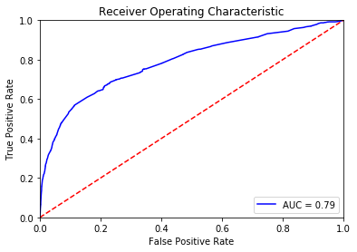

```python
plt.title('Receiver Operating Characteristic')
plt.plot(fpr, tpr, 'b', label = 'AUC = %0.2f' % auc)
plt.legend(loc = 'lower right')
plt.plot([0, 1], [0, 1],'r--')
plt.xlim([0, 1])
plt.ylim([0, 1])
plt.ylabel('True Positive Rate')
plt.xlabel('False Positive Rate')
plt.show()
```

**Computing the optimal threshold probability from the ROC curve parms**

```python
optimal_idx = np.argmax(tpr - fpr)
optimal_threshold = threshold[optimal_idx]
print(optimal_threshold)
```

```
0.1554615344569344
```

**Using the new threshold probability of 0.15 to re-compute the classes.**

```python
new_predicted_classes = probabilities.map(lambda x: 'yes' if x > optimal_threshold else 'no')
Y_test_encoded = Y_test.map(lambda x : 'yes' if x == 1 else 'no')
accuracy = sum(new_predicted_classes == Y_test_encoded) / len(Y_test)
print(accuracy)
```

```
0.850530063931375
```

**Computing the confusion matrix**

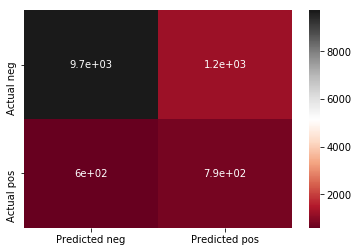

```python
new_predictions_encoded = new_predicted_classes.map(lambda x: 1 if x == 'yes' else 0)
from sklearn.metrics import confusion_matrix
confusion_mat = confusion_matrix(Y_test_encoded, new_predicted_classes)
confusion_df = pd.DataFrame(confusion_mat, index=['Actual neg','Actual pos'], columns=['Predicted neg','Predicted pos'])
_=sns.heatmap(confusion_df, cmap='RdGy', annot=True)
```

**Calculating precision and recall scores**

```python
from sklearn.metrics import precision_score, recall_score
precision_score(Y_test, new_predictions_encoded)
# print(predicted_classes)
```

```
0.38929798723613157
```

```python
recall_score(Y_test, new_predictions_encoded)
```

```
0.5680515759312321
```

### The final logistic regression model is found to have an accuracy score of 0.85 and precision score of 0.38

- AUC score for the best fit model was found to be 0.79

**In pursuit of improving the accuracy of the model, random forest classification is implemented in combination with GridSearch cross-validation**

# Random Forest classification

- using GridSearchCV for optimized hyperparameters
- n_estimators = 500
- For gridsearch, the max_depth values of 10, 20, 30, 40, 50, 60, 70, 80, 90, 100, None were iterated.

```python
from sklearn.ensemble import RandomForestClassifier
```

```python
rf_model = RandomForestClassifier(n_estimators=500, n_jobs=-1,random_state=123)
```

```python
from sklearn.model_selection import GridSearchCV
```

```python
param_grid=[{"max_depth":[10, 20, 30, 40, 50, 60, 70, 80, 90, 100, None]}]
gs=GridSearchCV(estimator=rf_model, \
               param_grid = param_grid,cv=10)
```

**Fitting the train data using gridsearch with RandomForestClassifier as the estimator class**

```python
gs.fit(X_train,Y_train)
```

```
GridSearchCV(cv=10, error_score='raise',
       estimator=RandomForestClassifier(bootstrap=True, class_weight=None, criterion='gini',
            max_depth=None, max_features='auto', max_leaf_nodes=None,
            min_impurity_decrease=0.0, min_impurity_split=None,
            min_samples_leaf=1, min_samples_split=2,
            min_weight_fraction_leaf=0.0, n_estimators=500, n_jobs=-1,
            oob_score=False, random_state=123, verbose=0, warm_start=False),
       fit_params=None, iid=True, n_jobs=1,
       param_grid=[{'max_depth': [10, 20, 30, 40, 50, 60, 70, 80, 90, 100, None]}],
       pre_dispatch='2*n_jobs', refit=True, return_train_score='warn',
       scoring=None, verbose=0)
```

**Gridsearch retuned the following as the best parameters for RandomforestClassifier**

```python
gs.best_params_
```

```
{'max_depth': 10}
```

**Predicting the test dataset using the best_estimator**

```python
predictions = gs.best_estimator_.predict(X_test)
prob_rtree = gs.best_estimator_.predict_proba(X_test)
```

```python
from sklearn.metrics import accuracy_score
accuracy_score(Y_test, predictions)
```

```
0.9013514607105284
```

```python
prob_list=pd.DataFrame(prob_rtree.tolist())
probabilities_rtree = prob_list[1]
auc = roc_auc_score(Y_test, probabilities_rtree)
print(auc)
```

```
0.7936403657248975
```

```python
fpr, tpr, threshold = roc_curve(Y_test, probabilities_rtree)
```

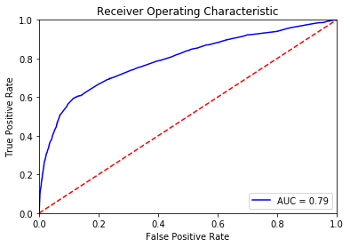

```python
plt.title('Receiver Operating Characteristic')
plt.plot(fpr, tpr, 'b', label = 'AUC = %0.2f' % auc)
plt.legend(loc = 'lower right')
plt.plot([0, 1], [0, 1],'r--')
plt.xlim([0, 1])
plt.ylim([0, 1])
plt.ylabel('True Positive Rate')
plt.xlabel('False Positive Rate')
plt.show()
```

**Plotting feature importances**

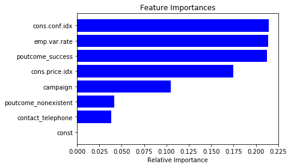

```python
features= X_train.columns[[0,1,2,3,4,5,6,7]]
importances = gs.best_estimator_.feature_importances_
indices = np.argsort(importances)

plt.figure(1)
plt.title('Feature Importances')
plt.barh(range(len(indices)), importances[indices], color='b', align='center')
plt.yticks(range(len(indices)), features[indices])
plt.xlabel('Relative Importance')
plt.show()
```

```python
from sklearn.metrics import precision_score, recall_score
precision_score(Y_test, predictions)
# print(predicted_classes)
```

```
0.6635859519408502
```

```python
recall_score(Y_test, predictions)
```

```
0.25716332378223494
```

### With RandomForest, with a max_depth of 10, the model produced an accuracy of 0.90 with an AUC score of 0.79 which is better than the binomial GLM.